# Dynamic Survival Analysis: Modelling the Hazard Function via Ordinary Differential Equations. rotterdam data

[F. Javier Rubio](https://sites.google.com/site/fjavierrubio67/) and J. Andres Christen

15 July, 2024

# Dynamic Survival Analysis: Modelling the Hazard Function via Ordinary Differential Equations

This document provides codes and information about the *hazard-Response* model proposed in Christen and Rubio (2024).

## The hazard-Response model

The hazard-Response model is defined through the system of ODEs:

$$\begin{cases}
h'(t) = \lambda h(t) \left(1 - \dfrac{h(t)}{\kappa}\right) -
\alpha q(t) h(t), & h(0) = h_0 \\
q'(t) = \beta q(t) \left( 1- \frac{q(t)}{\kappa} \right) -\alpha
q(t) h(t) , & q(0) = q_0 \\
H'(t) = h(t), & H(0) = 0,
\end{cases}$$

This model represents a particular version of the [competitive Lotka-Volterra equations](https://en.wikipedia.org/wiki/Competitive_Lotka%E2%80%93Volterra_equations), which is often used for modelling the growth on species in competition with harmful interactions.

The following R code presents an example from Christen and Rubio (2024) where we fit the hazard-Response model to the `rotterdam` data set from the R package `survival`. We present both Likelihood-based and Bayesian analyses.

# Data preparation

```r
#######################################################################################
# Data preparation
#######################################################################################

rm(list=ls())

# Required packages
library(deSolve)
library(survival)
library(ggplot2)
#library(devtools)
#install_github("FJRubio67/HazReg")
library(HazReg)
library(Rtwalk)
library(knitr)
library(spBayes)
library(bshazard)
```

```r
source("routines.R")
```

```r
#--------------------------------------------------------------------------------------------------
#--------------------------------------------------------------------------------------------------
# Data preparation
#--------------------------------------------------------------------------------------------------
#--------------------------------------------------------------------------------------------------


head(rotterdam)
```

```
##      pid year age meno  size grade nodes pgr  er hormon chemo rtime recur dtime
## 1393   1 1992  74    1  <=20     3     0  35 291      0     0  1799     0  1799
## 1416   2 1984  79    1 20-50     3     0  36 611      0     0  2828     0  2828
## 2962   3 1983  44    0  <=20     2     0 138   0      0     0  6012     0  6012
## 1455   4 1985  70    1 20-50     3     0   0  12      0     0  2624     0  2624
## 977    5 1983  75    1  <=20     3     0 260 409      0     0  4915     0  4915
## 617    6 1983  52    0  <=20     3     0 139 303      0     0  5888     0  5888
##      death
## 1393     0
## 1416     0
## 2962     0
## 1455     0
## 977      0
## 617      0
```

```r
dim(rotterdam)
```

```
## [1] 2982   15
```

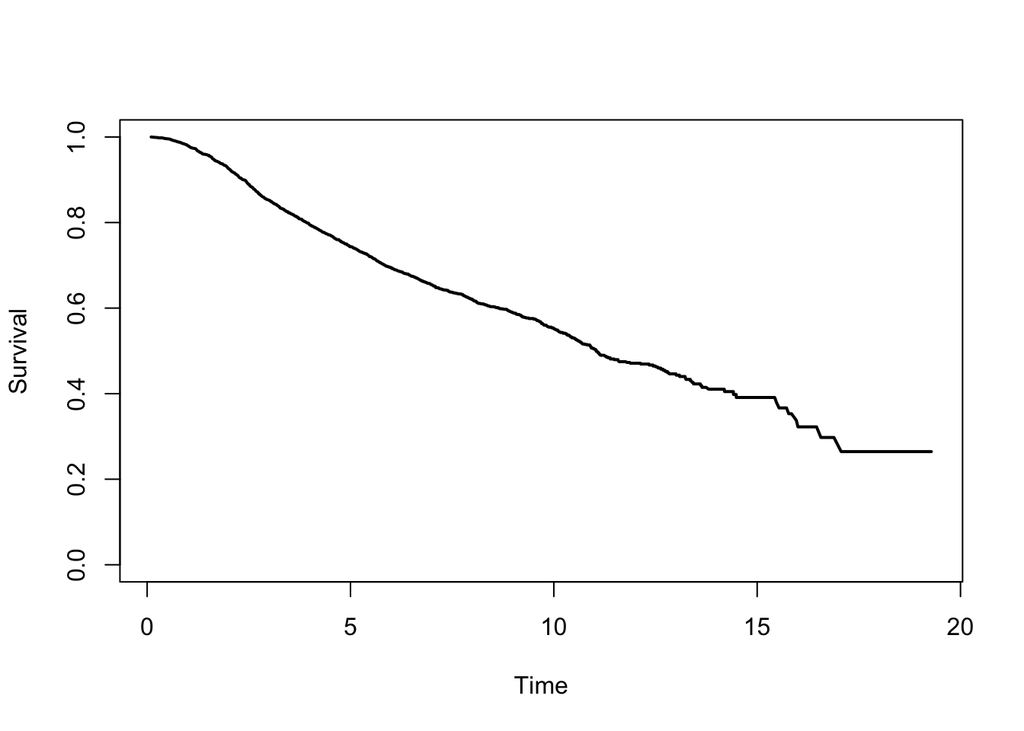

```r
# Kaplan-Meier estimator for the survival times
km <- survfit(Surv(rotterdam$dtime/365.24, rotterdam$death) ~ 1)

plot(km$time, km$surv, type = "l", col = "black", lwd = 2, lty = 1,
     ylim = c(0,1), xlab = "Time", ylab = "Survival")
```

```r
# New data frame: logical status, time in years, survival times sorted
df <- data.frame(time = rotterdam$dtime, status = rotterdam$death)
df$status <- as.logical(rotterdam$death)
df$time <- df$time/365.24

df <- df[order(df$time),]

# Required quantities
status <- as.logical(df$status)
t_obs <- df$time[status]
survtimes <- df$time
```

# Maximum Likelihood Analysis

## Weibull Model

```r
#==================================================================================================
# Maximum Likelihood Analysis
#==================================================================================================


#--------------------------------------------------------------------------------------------------
# Fitting a Weibull distribution
#--------------------------------------------------------------------------------------------------

# Initial value
initW <- c(0,0)

# Optimisation step
OPTW <- GHMLE(initW, survtimes, status, hstr = "baseline", dist = "Weibull", method = "nlminb", maxit = 10000)

MLEW <- exp(OPTW$OPT$par)

# Fitted Weibull hazard
fithw <- Vectorize(function(t) hweibull( t, exp(OPTW$OPT$par[1]), exp(OPTW$OPT$par[2]) ) )

# Fitted Weibull cumulative hazard
fitchw <- Vectorize(function(t) chweibull( t, exp(OPTW$OPT$par[1]), exp(OPTW$OPT$par[2]) ) )

# Fitted Weibull survival
fitsw <- Vectorize(function(t) exp(-chweibull( t, exp(OPTW$OPT$par[1]), exp(OPTW$OPT$par[2]) ) ))

# AIC
AICW <- 2*OPTW$OPT$objective + 2*length(OPTW$OPT$par)

# BIC
BICW <- 2*OPTW$OPT$objective + length(OPTW$OPT$par)*log(length(survtimes))
```

## The Power Generalised Weibull Model

```r
#==================================================================================================
# Maximum Likelihood Analysis
#==================================================================================================

#--------------------------------------------------------------------------------------------------
# Fitting a PGW distribution
#--------------------------------------------------------------------------------------------------

# Initial value
initPGW <- c(0,0,0)

# Optimisation step
OPTPGW <- GHMLE(initPGW, survtimes, status, hstr = "baseline", dist = "PGW",
                method = "nlminb", maxit = 10000)

MLEPGW <- exp(OPTPGW$OPT$par)

# Fitted Weibull hazard
fithpgw <- Vectorize(function(t) hpgw( t, MLEPGW[1], MLEPGW[2], MLEPGW[3] ) )

# Fitted Weibull cumulative hazard
fitchpgw <- Vectorize(function(t) chpgw( t, MLEPGW[1], MLEPGW[2], MLEPGW[3] ) )

# Fitted Weibull survival
fitspgw <- Vectorize(function(t) exp(-chpgw( t, MLEPGW[1], MLEPGW[2], MLEPGW[3] ) ))

# AIC
AICPGW <- 2*OPTPGW$OPT$objective + 2*length(OPTPGW$OPT$par)

# BIC
BICPGW <- 2*OPTPGW$OPT$objective + length(OPTPGW$OPT$par)*log(length(survtimes))
```

## The Hazard-Response Model

```r
#==================================================================================================
# MLE Analysis
#==================================================================================================

#--------------------------------------------------------------------------------------------------
# Hazard-Response ODE model for the hazard function: Solver solution
#--------------------------------------------------------------------------------------------------

# Initial point
initHR <- log(c(lambda = 2.5, kappa = 0.1, alpha = 2, beta = 2.))
h0 = 1e-2
q0 = 1e-6

# Optimisation step
OPTHR <- nlminb(initHR , log_likHR, control = list(iter.max = 10000))

OPTHR
```

```
## $par
##     lambda      kappa      alpha       beta
##  0.5381167 -2.3121004  1.9444865  1.5792623
##
## $objective
## [1] 4776.491
##
## $convergence
## [1] 1
##
## $iterations
## [1] 30
##
## $evaluations
## function gradient
##       78      178
##
## $message
## [1] "false convergence (8)"
```

```r
MLEHR <- c(exp(OPTHR$par[1:4]))

# AIC
AICHR <- 2*OPTHR$objective + 2*length(OPTHR$par)

# BIC
BICHR <- 2*OPTHR$objective + length(OPTHR$par)*log(length(survtimes))
```

## Comparison

```r
# AIC comparison
AICs <- c(AICW, AICPGW, AICHR)

AICs
```

```
## [1] 9638.298 9572.033 9560.982
```

```r
# Best model (Hazard-Response)
which.min(AICs)
```

```
## [1] 3
```

```r
# BIC comparison
BICs <- c(BICW, BICPGW, BICHR)

BICs
```

```
## [1] 9650.299 9590.034 9584.984
```

```r
# Best model (Hazard-Response)
which.min(BICs)
```

```
## [1] 3
```

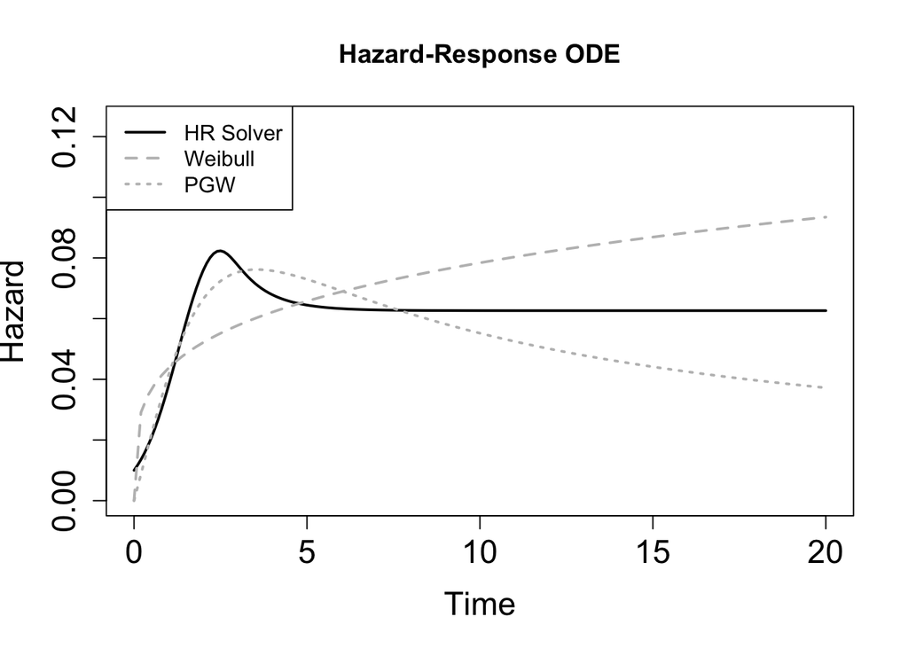

```r
# Fitted hazard and cumulative hazard: Solver
paramsHR  <- c(lambda = exp(OPTHR$par[1]), kappa = exp(OPTHR$par[2]), alpha = exp(OPTHR$par[3]), beta = exp(OPTHR$par[4]))
initHR0      <- c(h = h0, q = q0, H = 0 )
times = seq(0,20,by = 0.1)
out <- ode(initHR0, times, hazmodHR, paramsHR, method = "lsode", jacfunc = jacODE, jactype = "fullusr")


# Comparison: hazard functions
plot(as.matrix(out[,c(1,2)]), xlim = c(0,max(times)), ylim = c(0,0.125), type = "l", lwd = 2,
     xlab = "Time", ylab = "Hazard", main = "Hazard-Response ODE", cex.axis = 1.5, cex.lab = 1.5)
curve(fithw, 0, max(times), lwd= 2, lty = 2, col = "gray", add = TRUE)
curve(fithpgw, 0, max(times), lwd= 2, lty = 3, col = "gray", add = TRUE)
legend("topleft", legend = c("HR Solver","Weibull", "PGW"), lty = c(1,2,3),
       lwd = c(2,2,2), col = c("black","gray","gray"))
```

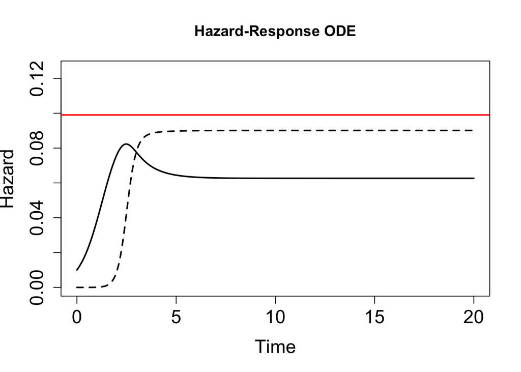

```r
# Comparison: hazard vs. treament
plot(as.matrix(out[,c(1,2)]), xlim = c(0,max(times)), ylim = c(0,0.125), type = "l", lwd = 2,
     xlab = "Time", ylab = "Hazard", main = "Hazard-Response ODE", cex.axis = 1.5, cex.lab = 1.5)
points(as.matrix(out[,c(1,3)]), xlim = c(0,max(times)), ylim = c(0,0.125), type = "l", lwd = 2, lty = 2,
     xlab = "Time", ylab = "Hazard", main = "Hazard-Response ODE", cex.axis = 1.5, cex.lab = 1.5)
abline(h = MLEHR[2], lwd = 2, col = "red")
```

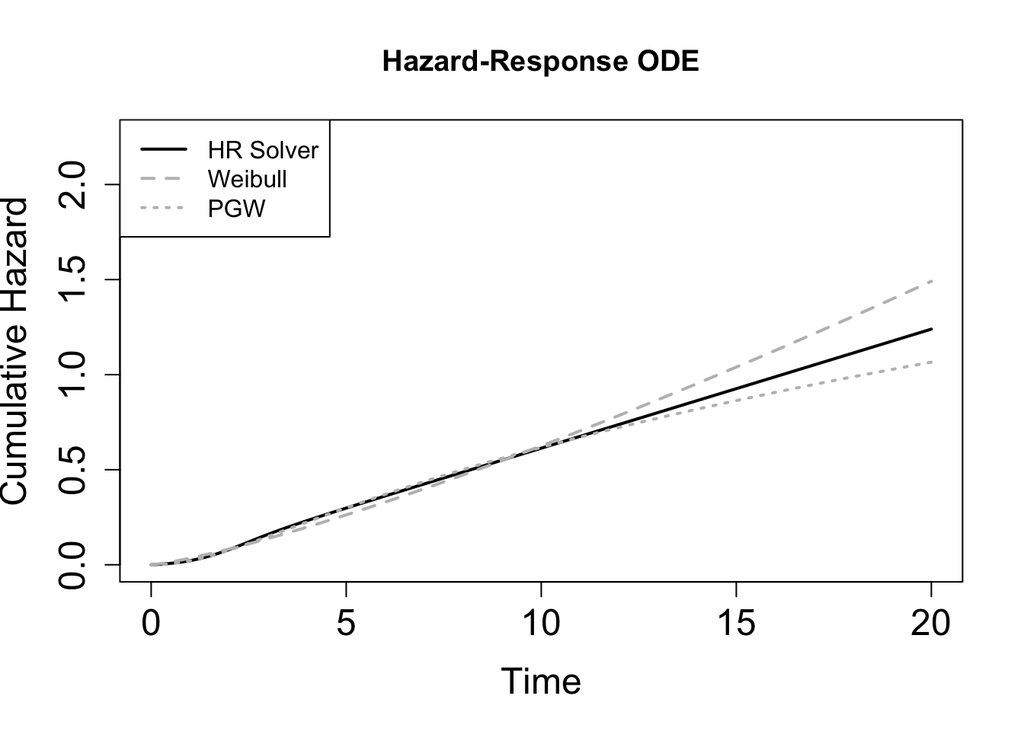

```r
# Comparison: cumulative hazard functions
plot(as.matrix(out[,c(1,4)]), xlim = c(0,max(times)), ylim = c(0,2.25), type = "l", lwd = 2,
     xlab = "Time", ylab = "Cumulative Hazard", main = "Hazard-Response ODE", cex.axis = 1.5, cex.lab = 1.5)
curve(fitchw, 0, max(times), lwd= 2, lty = 2, col = "gray", add = TRUE)
curve(fitchpgw, 0, max(times), lwd= 2, lty = 3, col = "gray", add = TRUE)
legend("topleft", legend = c("HR Solver","Weibull","PGW"), lty = c(1,2,3),
       lwd = c(2,2,2), col = c("black","gray","gray"))
```

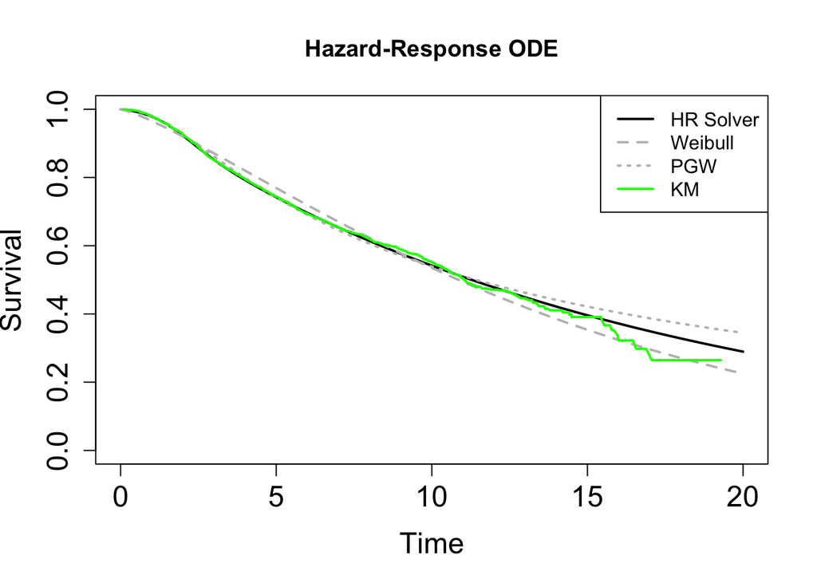

```r
# Comparison: survival functions
plot(as.vector(out[,1]),exp(-as.vector(out[,4])), xlim = c(0,max(times)), ylim = c(0,1), type = "l", lwd = 2,
     xlab = "Time", ylab = "Survival", main = "Hazard-Response ODE", cex.axis = 1.5, cex.lab = 1.5)
curve(fitsw, 0, max(times), lwd= 2, lty = 2, col = "gray", add = TRUE)
curve(fitspgw, 0, max(times), lwd= 2, lty = 3, col = "gray", add = TRUE)
points(km$time, km$surv, type = "l", col = "green", lwd = 2, lty = 1)
legend("topright", legend = c("HR Solver","Weibull","PGW","KM"), lty = c(1,2,3,1),
       lwd = c(2,2,2,2), col = c("black","gray","gray","green"))
```

# Bayesian Analysis

## Weibull

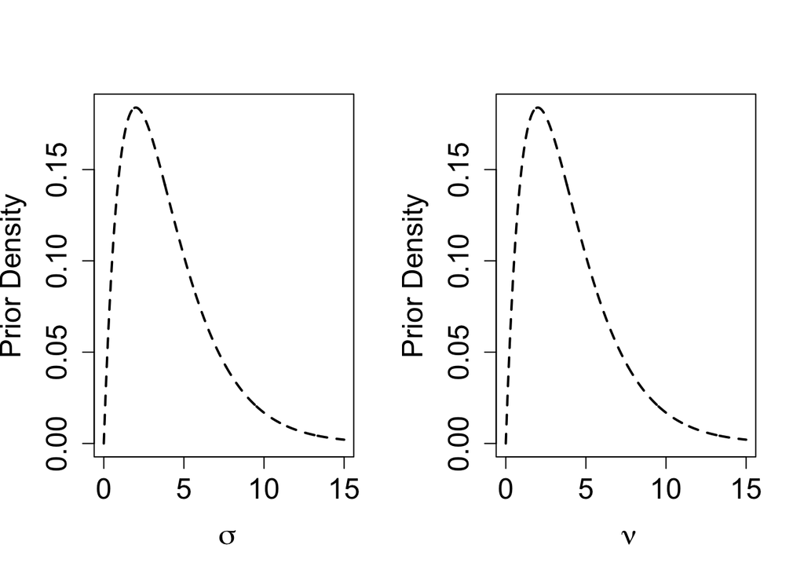

```r
#==================================================================================================
# Bayesian Analysis
#==================================================================================================

#--------------------------------------------------------------------------------------------------
# Priors
#--------------------------------------------------------------------------------------------------

par(mfrow = c(1,2))
p_sigmaW <- Vectorize(function(t) dgamma(t, shape = 2, scale = 2))
curve(p_sigmaW,0,15, n = 1000, xlab = ~sigma, ylab = "Prior Density",
      cex.axis = 1.5, cex.lab = 1.5, lwd = 2, lty = 2)

p_nuW <- Vectorize(function(t) dgamma(t, shape = 2, scale = 2))
curve(p_nuW,0,15, n = 1000, xlab = ~nu, ylab = "Prior Density",
      cex.axis = 1.5, cex.lab = 1.5, lwd = 2, lty = 2)
```

```r
par(mfrow = c(1,1))

#--------------------------------------------------------------------------------------------------
# Weibull model for the hazard function
#--------------------------------------------------------------------------------------------------

# Support
SupportW <- function(x) {   TRUE }

# Random initial points
X0W <- function(x) { OPTW$OPT$par + runif(2,-0.01,0.01) }

# twalk for analytic solution
set.seed(1234)
infoW <- Runtwalk( dim=2,  Tr=110000,  Obj=log_postW, Supp=SupportW,
                   x0=X0W(), xp0=X0W(), PlotLogPost = FALSE)
```

```
## This is the twalk for R.
## Evaluating the objective density at initial values.
## Opening 6 X 110001 matrix to save output.  Sampling (no graphics mode).
```

```r
# Posterior sample after burn-in and thinning
ind=seq(10000,110000,100)

# Summaries
summW <- apply(exp(infoW$output[ind,]),2,summary)
colnames(summW) <- c("sigma","nu")
kable(summW, digits = 3)
```

|  | sigma | nu |
| --- | --- | --- |
| Min. | 13.293 | 1.165 |
| 1st Qu. | 14.256 | 1.235 |
| Median | 14.496 | 1.255 |
| Mean | 14.504 | 1.255 |
| 3rd Qu. | 14.744 | 1.276 |
| Max. | 15.952 | 1.372 |

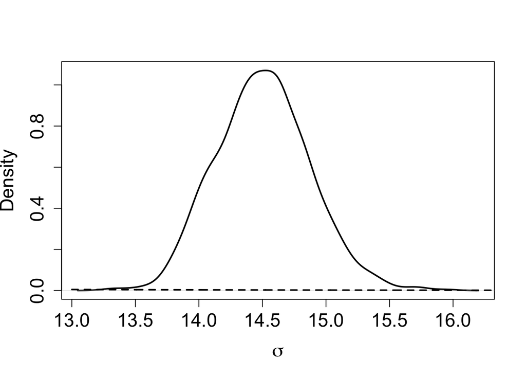

```r
# KDEs
sigmapW <- exp(infoW$output[,1][ind])
nupW <- exp(infoW$output[,2][ind])

plot(density(sigmapW), main = "", xlab = expression(sigma), ylab = "Density",
     cex.axis = 1.5, cex.lab = 1.5, lwd = 2)
curve(p_sigmaW,13,17, n = 1000, xlab = ~lambda, ylab = "Prior Density",
      cex.axis = 1.5, cex.lab = 1.5, lwd = 2, lty = 2, add = TRUE)
```

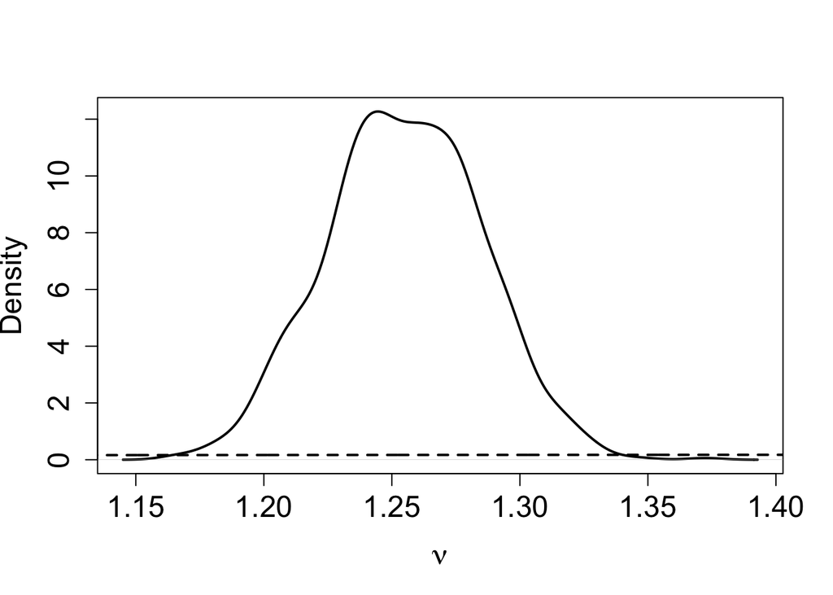

```r
plot(density(nupW), main = "", xlab = expression(nu), ylab = "Density",
     cex.axis = 1.5, cex.lab = 1.5, lwd = 2)
curve(p_nuW,1.1,1.5, n = 1000, xlab = ~kappa, ylab = "Prior Density",
      cex.axis = 1.5, cex.lab = 1.5, lwd = 2, lty = 2, add = TRUE)
```

## The Power Generalised Weibull Model

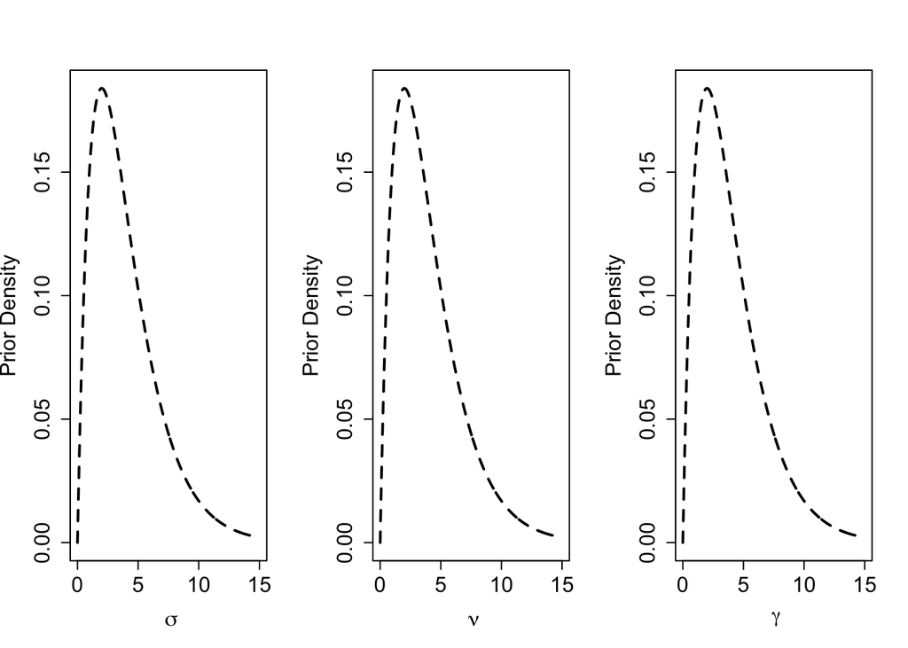

```r
#==================================================================================================
# Bayesian Analysis
#==================================================================================================

#--------------------------------------------------------------------------------------------------
# Priors
#--------------------------------------------------------------------------------------------------

par(mfrow = c(1,3))
p_sigmaPGW <- Vectorize(function(t) dgamma(t, shape = 2, scale = 2))
curve(p_sigmaPGW,0,15, n = 1000, xlab = ~sigma, ylab = "Prior Density",
      cex.axis = 1.5, cex.lab = 1.5, lwd = 2, lty = 2)

p_nuPGW <- Vectorize(function(t) dgamma(t, shape = 2, scale = 2))
curve(p_nuPGW,0,15, n = 1000, xlab = ~nu, ylab = "Prior Density",
      cex.axis = 1.5, cex.lab = 1.5, lwd = 2, lty = 2)

p_gammaPGW <- Vectorize(function(t) dgamma(t, shape = 2, scale = 2))
curve(p_gammaPGW,0,15, n = 1000, xlab = ~gamma, ylab = "Prior Density",
      cex.axis = 1.5, cex.lab = 1.5, lwd = 2, lty = 2)
```

```r
par(mfrow = c(1,1))

#--------------------------------------------------------------------------------------------------
# Weibull model for the hazard function
#--------------------------------------------------------------------------------------------------

# Support
SupportPGW <- function(x) {   TRUE }

# Random initial points
X0PGW <- function(x) { OPTPGW$OPT$par + runif(3,-0.01,0.01) }


# twalk for analytic solution
set.seed(1234)
infoPGW <- Runtwalk( dim=3,  Tr=110000,  Obj=log_postPGW, Supp=SupportPGW,
                     x0=X0PGW(), xp0=X0PGW(), PlotLogPost = FALSE)
```

```
## This is the twalk for R.
## Evaluating the objective density at initial values.
## Opening 8 X 110001 matrix to save output.  Sampling (no graphics mode).
```

```r
# Posterior sample after burn-in and thinning
ind=seq(10000,110000,100)

# Summaries
summPGW <- apply(exp(infoPGW$output[ind,]),2,summary)
colnames(summPGW) <- c("sigma","nu","gamma")
kable(summPGW, digits = 3)
```

|  | sigma | nu | gamma |
| --- | --- | --- | --- |
| Min. | 2.184 | 1.686 | 3.651 |
| 1st Qu. | 2.654 | 1.926 | 4.992 |
| Median | 2.825 | 2.012 | 5.425 |
| Mean | 2.861 | 2.016 | 5.451 |
| 3rd Qu. | 3.029 | 2.097 | 5.870 |
| Max. | 4.006 | 2.439 | 7.672 |

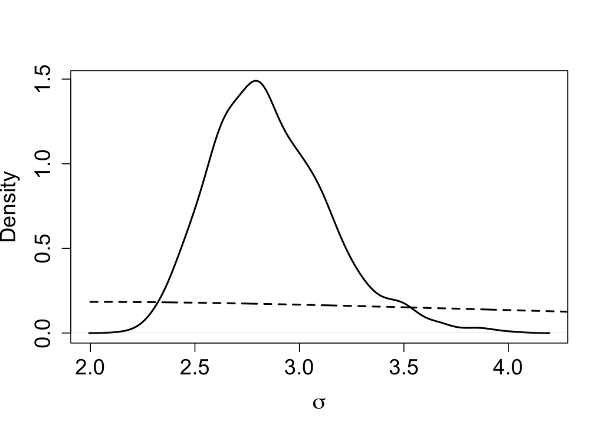

```r
# KDEs
sigmapPGW <- exp(infoPGW$output[,1][ind])
nupPGW <- exp(infoPGW$output[,2][ind])
gammapPGW <- exp(infoPGW$output[,3][ind])

plot(density(sigmapPGW), main = "", xlab = expression(sigma), ylab = "Density",
     cex.axis = 1.5, cex.lab = 1.5, lwd = 2)
curve(p_sigmaPGW,2,5, n = 1000, xlab = ~lambda, ylab = "Prior Density",
      cex.axis = 1.5, cex.lab = 1.5, lwd = 2, lty = 2, add = TRUE)
```

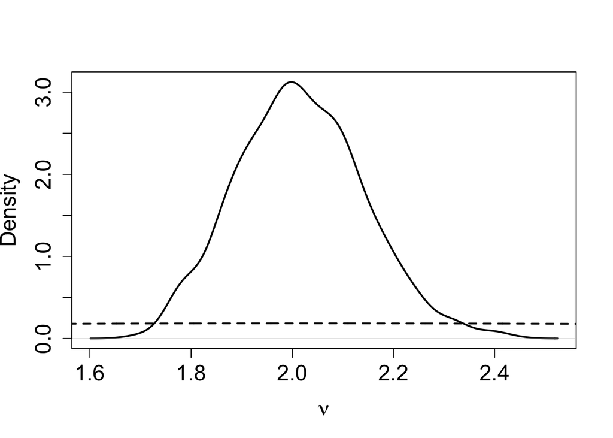

```r
plot(density(nupPGW), main = "", xlab = expression(nu), ylab = "Density",
     cex.axis = 1.5, cex.lab = 1.5, lwd = 2)
curve(p_nuPGW,1.5,2.7, n = 1000, xlab = ~kappa, ylab = "Prior Density",
      cex.axis = 1.5, cex.lab = 1.5, lwd = 2, lty = 2, add = TRUE)
```

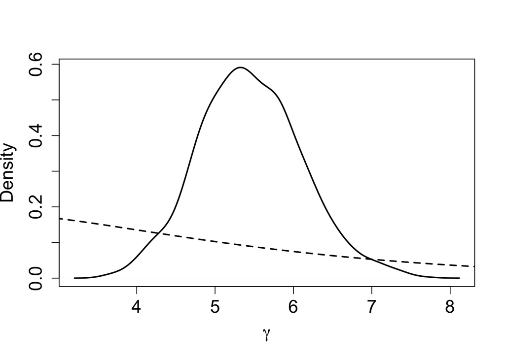

```r
plot(density(gammapPGW), main = "", xlab = expression(gamma), ylab = "Density",
     cex.axis = 1.5, cex.lab = 1.5, lwd = 2)
curve(p_gammaPGW,0,15, cex.lab = 1.5, lwd = 2, lty = 2, add = TRUE)
```

## The Hazard-Response Model

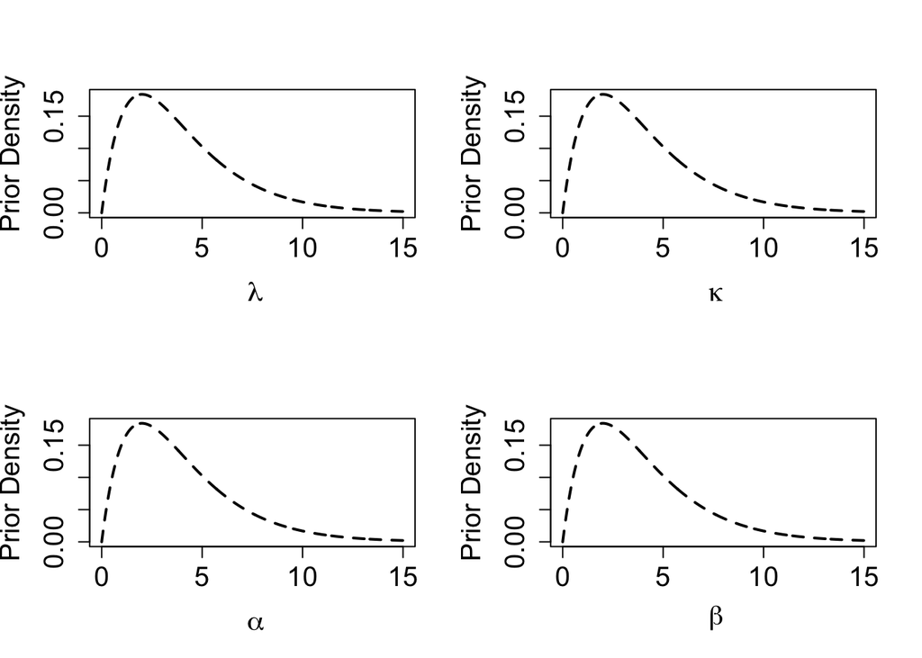

```r
#==================================================================================================
# Bayesian Analysis
#==================================================================================================

#--------------------------------------------------------------------------------------------------
# Priors
#--------------------------------------------------------------------------------------------------

par(mfrow = c(2,2))
p_lambdaHR <- Vectorize(function(t) dgamma(t, shape = 2, scale = 2))
curve(p_lambdaHR,0,15, n = 1000, xlab = ~lambda, ylab = "Prior Density",
      cex.axis = 1.5, cex.lab = 1.5, lwd = 2, lty = 2)

p_kappaHR <- Vectorize(function(t) dgamma(t, shape = 2, scale = 2))
curve(p_kappaHR,0,15, n = 1000, xlab = ~kappa, ylab = "Prior Density",
      cex.axis = 1.5, cex.lab = 1.5, lwd = 2, lty = 2)

p_alphaHR <- Vectorize(function(t) dgamma(t, shape = 2, scale = 2))
curve(p_alphaHR,0,15, n = 1000, xlab = ~alpha, ylab = "Prior Density",
      cex.axis = 1.5, cex.lab = 1.5, lwd = 2, lty = 2)

p_betaHR <- Vectorize(function(t) dgamma(t, shape = 2, scale = 2))
curve(p_betaHR,0,15, n = 1000, xlab = ~beta, ylab = "Prior Density",
      cex.axis = 1.5, cex.lab = 1.5, lwd = 2, lty = 2)
```

```r
par(mfrow = c(1,1))


#--------------------------------------------------------------------------------------------------
# Hazard-Response ODE model for the hazard function: Solver solution
#--------------------------------------------------------------------------------------------------


n.batch <- 1100
batch.length <- 100

lp <- function(par) -log_postHR(par)

inits <- OPTHR$par
```

```r
set.seed(1234)
infoHR <- adaptMetropGibbs(ltd=lp, starting=inits, accept.rate=0.44, batch=n.batch,
                           batch.length=batch.length, report=100, verbose=FALSE)
```

```r
chainHR <- infoHR$p.theta.samples[,1:4]

# Burning and thinning the chain
burn <- 1e4
thin <- 100
NS <- n.batch*batch.length
ind <- seq(burn,NS,thin)



# Summaries
summHR <- apply(exp(chainHR[ind,1:4]),2,summary)
colnames(summHR) <- c("lambda","kappa","alpha","beta")
kable(summHR, digits = 3)
```

|  | lambda | kappa | alpha | beta |
| --- | --- | --- | --- | --- |
| Min. | 1.283 | 0.068 | 1.072 | 1.634 |
| 1st Qu. | 1.638 | 0.081 | 5.287 | 4.078 |
| Median | 1.807 | 0.091 | 6.315 | 4.692 |
| Mean | 1.821 | 0.099 | 6.019 | 4.691 |
| 3rd Qu. | 1.995 | 0.106 | 6.908 | 5.231 |
| Max. | 2.636 | 0.294 | 9.849 | 8.600 |

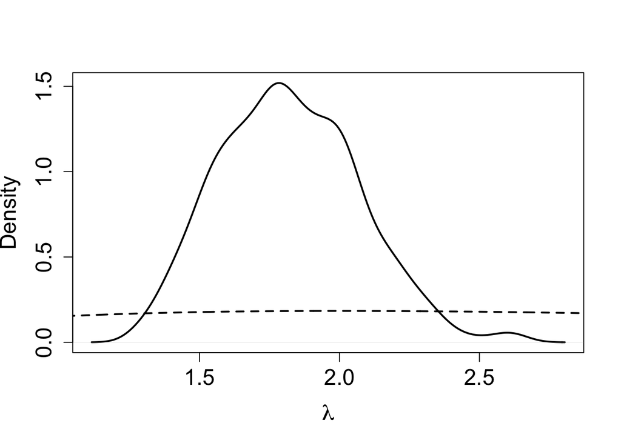

```r
# KDEs
lambdapHR <- exp(chainHR[,1][ind])
kappapHR <- exp(chainHR[,2][ind])
alphapHR <- exp(chainHR[,3][ind])
betapHR <- exp(chainHR[,4][ind])


plot(density(lambdapHR), main = "", xlab = expression(lambda), ylab = "Density",
     cex.axis = 1.5, cex.lab = 1.5, lwd = 2)
curve(p_lambdaHR,0,3, n = 1000, xlab = ~lambda, ylab = "Prior Density",
      cex.axis = 1.5, cex.lab = 1.5, lwd = 2, lty = 2, add = TRUE)
```

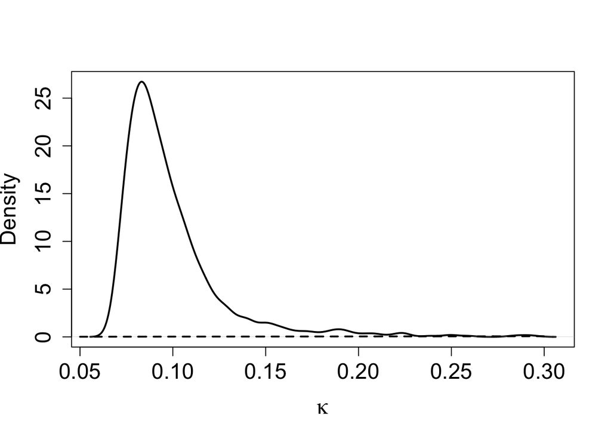

```r
plot(density(kappapHR), main = "", xlab = expression(kappa), ylab = "Density",
     cex.axis = 1.5, cex.lab = 1.5, lwd = 2)
curve(p_kappaHR,0.05,0.3, n = 1000, xlab = ~kappa, ylab = "Prior Density",
      cex.axis = 1.5, cex.lab = 1.5, lwd = 2, lty = 2, add = TRUE)
```

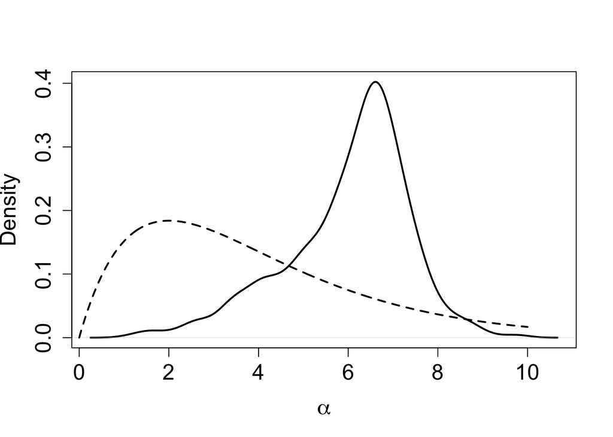

```r
plot(density(alphapHR), main = "", xlab = expression(alpha), ylab = "Density",
     cex.axis = 1.5, cex.lab = 1.5, lwd = 2)
curve(p_alphaHR,0,10, n = 1000, xlab = ~alpha, ylab = "Prior Density",
      cex.axis = 1.5, cex.lab = 1.5, lwd = 2, lty = 2, add = TRUE)
```

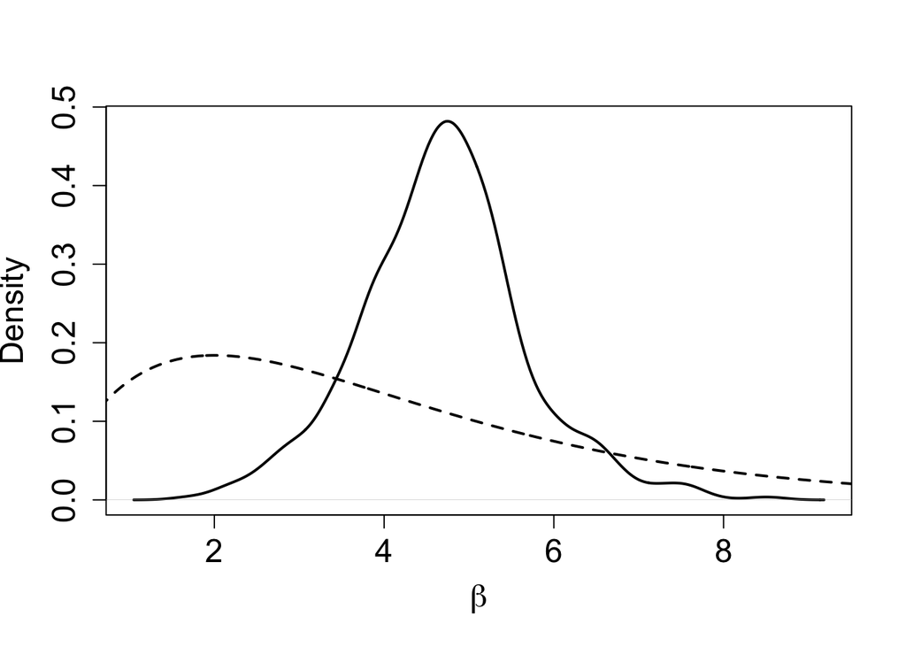

```r
plot(density(betapHR), main = "", xlab = expression(beta), ylab = "Density",
     cex.axis = 1.5, cex.lab = 1.5, lwd = 2)
curve(p_betaHR,0,15, n = 1000, xlab = ~beta, ylab = "Prior Density",
      cex.axis = 1.5, cex.lab = 1.5, lwd = 2, lty = 2, add = TRUE)
```

## Predictive Hazard functions

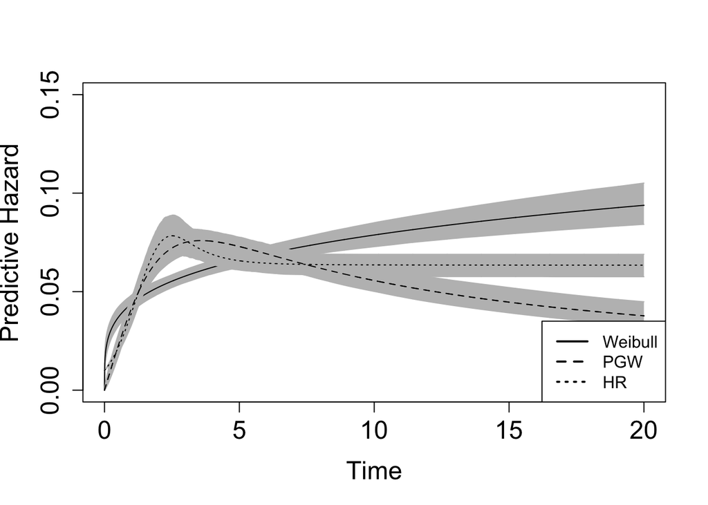

```r
#---------------------------------------------------------------------------------------
# Predictive Hazard functions
#---------------------------------------------------------------------------------------

# Predictive Weibull hazard
predhW <- Vectorize(function(t){
  num <- den <- temp <- vector()
  for(i in 1:length(ind)){
    num[i] <- exp(-chweibull( t, sigmapW[i], nupW[i]))*hweibull( t, sigmapW[i], nupW[i])
    den[i] <- exp(-chweibull( t, sigmapW[i], nupW[i]))
  }
  return(mean(num)/mean(den))
})

# Predictive PGW
predhPGW <- Vectorize(function(t){
  num <- den <- temp <- vector()
  for(i in 1:length(ind)) num[i] <- exp(-chpgw( t, sigmapPGW[i], nupPGW[i], gammapPGW[i]))*
      hpgw( t, sigmapPGW[i], nupPGW[i], gammapPGW[i])
  for(i in 1:length(ind)) den[i] <- exp(-chpgw( t, sigmapPGW[i], nupPGW[i], gammapPGW[i]))
  return(mean(num)/mean(den))
})



# Creating the credible envelopes
tvec <- seq(0,20,by = 0.01)
ntvec <- length(tvec)

# Weibull
hCIW <- matrix(0, ncol = ntvec, nrow = length(ind))

for(j in 1:length(ind)){
  for(k in 1:ntvec){
    hCIW[j,k ] <- hweibull( tvec[k],sigmapW[j], nupW[j])
  }
}

hW <-  predhW(tvec)


hCIWL <- apply(hCIW, 2, ql)
hCIWU <- apply(hCIW, 2, qu)

# PGW
hCIPGW <- matrix(0, ncol = ntvec, nrow = length(ind))

for(j in 1:length(ind)){
  for(k in 1:ntvec){
    hCIPGW[j,k ] <- hpgw( tvec[k],sigmapPGW[j], nupPGW[j], gammapPGW[j])
  }
}

hPGWs <-  predhPGW(tvec)

hCIPGWL <- apply(hCIPGW, 2, ql)
hCIPGWU <- apply(hCIPGW, 2, qu)

# Hazard-Response

hCIHR <- matrix(0, ncol = ntvec, nrow = length(ind))
chCIHR <- matrix(0, ncol = ntvec, nrow = length(ind))
SCIHR <- matrix(0, ncol = ntvec, nrow = length(ind))
qCIHR <- matrix(0, ncol = ntvec, nrow = length(ind))

for(j in 1:length(ind)){
  paramsHRj  <- c(lambda = lambdapHR[j], kappa = kappapHR[j], alpha = alphapHR[j],
                  beta = betapHR[j])
  initHRj      <- c(h = h0, q = q0, H = 0 )
  outj <- ode(initHRj, tvec, hazmodHR, paramsHRj, method = "lsode", jacfunc = jacODE, jactype = "fullusr")

  hCIHR[j, ] <- outj[,2]
  qCIHR[j, ] <- outj[,3]
  chCIHR[j, ] <- outj[,4]
  SCIHR[j, ] <- exp(-outj[,4])

}


numHR <- hCIHR*exp(-chCIHR)
denHR <- exp(-chCIHR)

hpredHR <- colMeans(numHR)/colMeans(denHR)


hCIHRL <- apply(hCIHR, 2, ql)
hCIHRU <- apply(hCIHR, 2, qu)

qCIHRL <- apply(qCIHR, 2, ql)
qCIHRU <- apply(qCIHR, 2, qu)


# Plots

# Weibull
plot(tvec,  hW, type = "l", ylim = c(0,0.15), xlab = "Time", ylab = "Predictive Hazard",
     cex.axis = 1.5, cex.lab = 1.5, lwd =1)
points(tvec,  hCIWL, col = "gray", type = "l")
points(tvec,  hCIWU, col = "gray", type = "l")
polygon(c(tvec, rev(tvec)), c(hCIWL[order(tvec)], rev(hCIWU[order(tvec)])),
        col = "gray", border = NA)
points(tvec,  hW,type = "l", col = "black", lwd = 1)

# PGW
points(tvec,  hPGWs, type = "l", xlab = "Time", ylab = "Predictive Hazard",
       cex.axis = 1.5, cex.lab = 1.5, lwd =1, lty = 2)
points(tvec,  hCIPGWL, col = "gray", type = "l")
points(tvec,  hCIPGWU, col = "gray", type = "l")
polygon(c(tvec, rev(tvec)), c(hCIPGWL[order(tvec)], rev(hCIPGWU[order(tvec)])),
        col = "gray", border = NA)
points(tvec,  hPGWs,type = "l", col = "black", lwd = 1, lty =2)

# Hazard-Response
points(tvec,  hpredHR, type = "l", xlab = "Time", ylab = "Predictive Hazard",
       cex.axis = 1.5, cex.lab = 1.5, lwd =1, lty = 3)
points(tvec,  hCIHRL, col = "gray", type = "l")
points(tvec,  hCIHRU, col = "gray", type = "l")
polygon(c(tvec, rev(tvec)), c(hCIHRL[order(tvec)], rev(hCIHRU[order(tvec)])),
        col = "gray", border = NA)
points(tvec,  hpredHR,type = "l", col = "black", lwd = 1, lty =3)
points(tvec,  hPGWs,type = "l", col = "black", lwd = 1, lty =2)
legend("bottomright", legend = c("Weibull", "PGW", "HR"), lty = c(1,2,3),
       lwd = c(2,2,2), col = c("black","black","black"))
```

## Predictive Hazard vs. Response

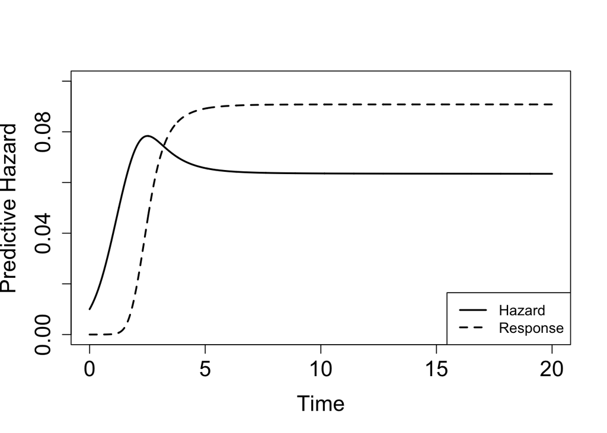

```r
# Hazard vs. Response
plot(tvec,  hpredHR, type = "l", xlab = "Time", ylab = "Predictive Hazard",
       cex.axis = 1.5, cex.lab = 1.5, lwd =2, lty = 1, ylim = c(0,0.1))

qpredHR <- colMeans(qCIHR)

points(tvec,  qpredHR, type = "l", xlab = "Time", ylab = "Predictive Hazard",
       cex.axis = 1.5, cex.lab = 1.5, lwd =2, lty = 2)

legend("bottomright", legend = c("Hazard","Response"), lty = c(1,2),
       lwd = c(2,2), col = c("black","black"))
```

## Predictive Survival functions

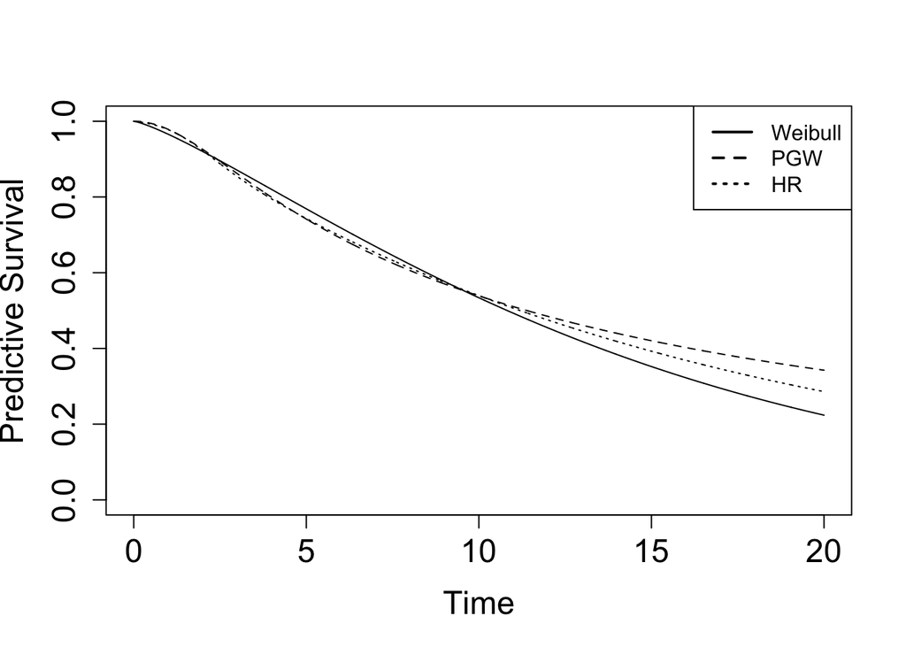

```r
#---------------------------------------------------------------------------------------
# Predictive Survival functions
#---------------------------------------------------------------------------------------

# Predictive Weibull survival
predsW <- Vectorize(function(t){
  temp <- vector()
  for(i in 1:length(ind)) temp[i] <- exp(-chweibull(t,sigmapW[i], nupW[i]) )
  return(mean(temp))
})

# Predictive PGW survival
predsPGW <- Vectorize(function(t){
  temp <- vector()
  for(i in 1:length(ind)) temp[i] <- exp(-chpgw( t,sigmapPGW[i], nupPGW[i], gammapPGW[i]) )
  return(mean(temp))
})


# Predictive Hazard-Response survival: Solver solution
predsHR <- colMeans(denHR)


# Weibull
SCIW <- matrix(0, ncol = ntvec, nrow = length(ind))

for(j in 1:length(ind)){
  for(k in 1:ntvec){
    SCIW[j,k ] <- exp(-chweibull( tvec[k],sigmapW[j], nupW[j]))
  }
}

SW <-  predsW(tvec)

SCIWL <- apply(SCIW, 2, ql)
SCIWU <- apply(SCIW, 2, qu)

# PGW

SCIPGW <- matrix(0, ncol = ntvec, nrow = length(ind))

for(j in 1:length(ind)){
  for(k in 1:ntvec){
    SCIPGW[j,k ] <- exp(-chpgw( tvec[k],sigmapPGW[j], nupPGW[j], gammapPGW[j]))
  }
}

SPGW <-  predsPGW(tvec)

SCIPGWL <- apply(SCIPGW, 2, ql)
SCIPGWU <- apply(SCIPGW, 2, qu)


# Hazard-Response
SpredCIHR <- colMeans(denHR)

SCIHRL <- apply(SCIHR, 2, ql)
SCIHRU <- apply(SCIHR, 2, qu)

# Plots (no credible envelopes)

# Weibull
plot(tvec,  SW, type = "l", ylim = c(0,1), xlab = "Time", ylab = "Predictive Survival",
     cex.axis = 1.5, cex.lab = 1.5, lwd =1)

# PGW
points(tvec,  SPGW, type = "l", ylim = c(0,1), xlab = "Time", ylab = "Predictive Survival",
       cex.axis = 1.5, cex.lab = 1.5, lwd =1, lty = 2)

# Hazard-Response
points(tvec,  SpredCIHR, type = "l", ylim = c(0,1), xlab = "Time", ylab = "Predictive Survival",
       cex.axis = 1.5, cex.lab = 1.5, lwd =1, lty = 3)

legend("topright", legend = c("Weibull", "PGW", "HR"), lty = c(1,2,3),
       lwd = c(2,2,2), col = c("black","black","black"))
```

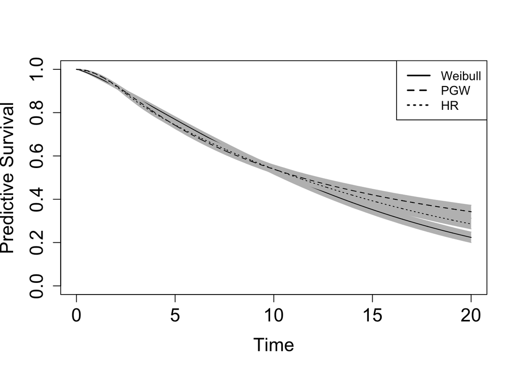

```r
# Plots (with credible envelopes)

# Weibull
plot(tvec,  SW, type = "l", ylim = c(0,1), xlab = "Time", ylab = "Predictive Survival",
     cex.axis = 1.5, cex.lab = 1.5, lwd =1)
points(tvec,  SCIWL, col = "gray", type = "l")
points(tvec,  SCIWU, col = "gray", type = "l")
polygon(c(tvec, rev(tvec)), c(SCIWL[order(tvec)], rev(SCIWU[order(tvec)])),
        col = "gray", border = NA)
points(tvec,  SW,type = "l", col = "black", lwd = 1)

# PGW
points(tvec,  SPGW, type = "l", ylim = c(0,1), xlab = "Time", ylab = "Predictive Survival",
       cex.axis = 1.5, cex.lab = 1.5, lwd =1, lty = 2)
points(tvec,  SCIPGWL, col = "gray", type = "l")
points(tvec,  SCIPGWU, col = "gray", type = "l")
polygon(c(tvec, rev(tvec)), c(SCIPGWL[order(tvec)], rev(SCIPGWU[order(tvec)])),
        col = "gray", border = NA)
points(tvec,  SPGW,type = "l", col = "black", lwd = 1, lty =2)

# Hazard-Response
points(tvec,  SpredCIHR, type = "l", ylim = c(0,1), xlab = "Time", ylab = "Predictive Survival",
       cex.axis = 1.5, cex.lab = 1.5, lwd =1, lty = 3)
points(tvec,  SCIHRL, col = "gray", type = "l")
points(tvec,  SCIHRU, col = "gray", type = "l")
polygon(c(tvec, rev(tvec)), c(SCIHRL[order(tvec)], rev(SCIHRU[order(tvec)])),
        col = "gray", border = NA)
points(tvec,  SpredCIHR,type = "l", col = "black", lwd = 1, lty =3)

points(tvec,  SPGW,type = "l", col = "black", lwd = 1, lty =2)

legend("topright", legend = c("Weibull", "PGW", "HR"), lty = c(1,2,3),
       lwd = c(2,2,2), col = c("black","black","black"))
```

# Comparison with a spline-based estimator

Now, we present a comparison of the estimated hazard function with that obtained with the R command `bshazard` from the R package `bshazard`. This estimator is based on B-Splines. See [bshazard: Nonparametric Smoothing of the Hazard Function](https://cran.r-project.org/package=bshazard).

```r
# fitting the estimator
fit <- bshazard(Surv(df$time, df$status) ~ 1, data = df, nbin = 100, degree = 3, verbose = FALSE)
```

```
## NOTE: entry.status has been set to 0 for all.
```

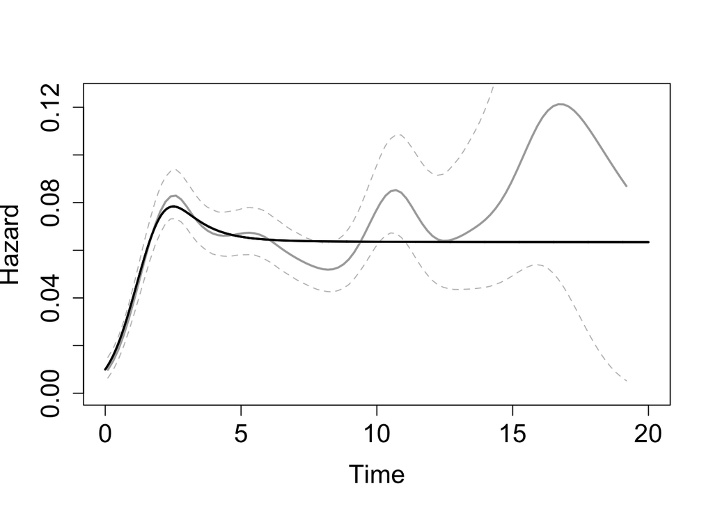

```r
# Hazard vs. Response
plot(tvec,  hpredHR, type = "l", xlab = "Time", ylab = "Hazard",
       cex.axis = 1.5, cex.lab = 1.5, lwd =2, lty = 1, ylim = c(0,0.125))

# bshazard with confidence intervals
points(fit$time, fit$hazard, type='l', lwd = 2, ylim = c(0,0.15), col = "darkgray")
lines(fit$time, fit$lower.ci, lty = 2, lwd = 1, col = "gray")
lines(fit$time, fit$upper.ci, lty = 2, lwd = 1, col = "gray")

# Hazard vs. Response
points(tvec,  hpredHR, type = "l", xlab = "Time", ylab = "Hazard",
     cex.axis = 1.5, cex.lab = 1.5, lwd =2, lty = 1, ylim = c(0,0.15))
```

# Sensitivity Analysis

In this section, we provide a sensitivity analysis where instead of fixing the initial conditions $h_0$ and $q_0$, we set a prior on these parameters. These priors are consistent with the choice of the initial conditions chosen in the previous study, in the sense that their mean coincides with the values previously chosen. For $h_0$ we choose a gamma prior with shape parameter $2$ and scale $5\times 10^{-3}$. For $q_0$ we choose a gamma prior with shape parameter $2$ and scale $5\times 10^{-7}$. We can see that the posterior distribution of $h_0$ and $q_0$ is very similar to the prior, indicating weak identifiability of these parameters.

```r
# Log-posterior (unknown initial conditions)
lpX <- function(par) -log_postHRX(par)

initsX <- c(OPTHR$par,h0,q0)


## ----include=FALSE----------------------------------------------------------------------------------------
set.seed(1234)
infoHRX <- adaptMetropGibbs(ltd=lpX, starting=initsX, accept.rate=0.44, batch=n.batch,
                           batch.length=batch.length, report=100, verbose=FALSE)


chainHRX <- infoHRX$p.theta.samples[,1:6]


# Summaries
summHRX <- apply(exp(chainHRX[ind,1:6]),2,summary)
colnames(summHRX) <- c("lambda","kappa","alpha","beta","h0","q0")
kable(summHRX, digits = 3)
```

|  | lambda | kappa | alpha | beta | h0 | q0 |
| --- | --- | --- | --- | --- | --- | --- |
| Min. | 1.293 | 0.066 | 0.253 | 1.324 | 0.000 | 0 |
| 1st Qu. | 1.632 | 0.082 | 5.438 | 4.114 | 0.004 | 0 |
| Median | 1.799 | 0.092 | 6.290 | 4.721 | 0.008 | 0 |
| Mean | 1.813 | 0.101 | 6.093 | 4.741 | 0.010 | 0 |
| 3rd Qu. | 1.980 | 0.106 | 6.947 | 5.319 | 0.013 | 0 |
| Max. | 2.941 | 0.274 | 9.363 | 11.011 | 0.044 | 0 |

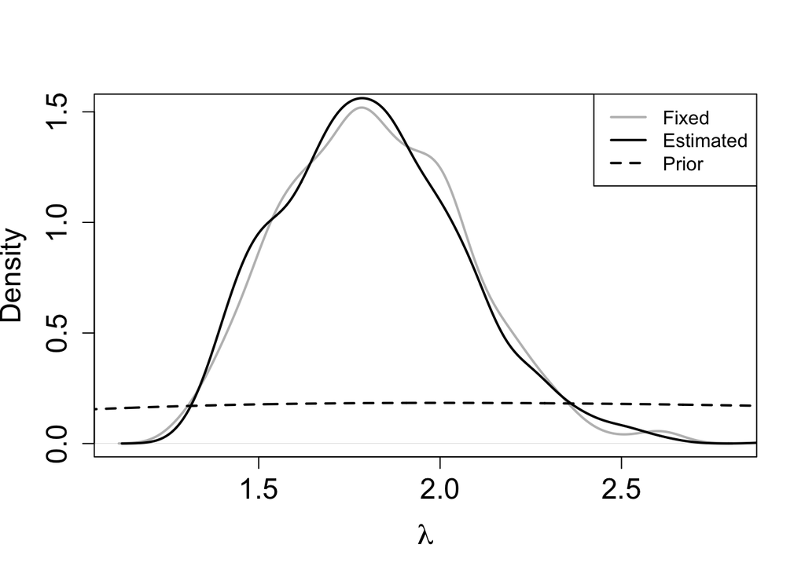

```r
# KDEs
lambdapHRX <- exp(chainHRX[,1][ind])
kappapHRX <- exp(chainHRX[,2][ind])
alphapHRX <- exp(chainHRX[,3][ind])
betapHRX <- exp(chainHRX[,4][ind])
h0pHRX <- exp(chainHRX[,5][ind])
q0pHRX <- exp(chainHRX[,6][ind])


# Comparison


plot(density(lambdapHR), main = "", xlab = expression(lambda), ylab = "Density",
     cex.axis = 1.5, cex.lab = 1.5, lwd = 2, col = "gray")
points(density(lambdapHRX), main = "", xlab = expression(lambda), ylab = "Density",
     cex.axis = 1.5, cex.lab = 1.5, lwd = 2, type = "l")
curve(p_lambdaHR,0,3, n = 1000, xlab = ~lambda, ylab = "Prior Density",
      cex.axis = 1.5, cex.lab = 1.5, lwd = 2, lty = 2, add = TRUE)
legend("topright", legend = c("Fixed", "Estimated","Prior"), col = c("gray","black","black"),
       lty = c(1,1,2), lwd = c(2,2,2))
```

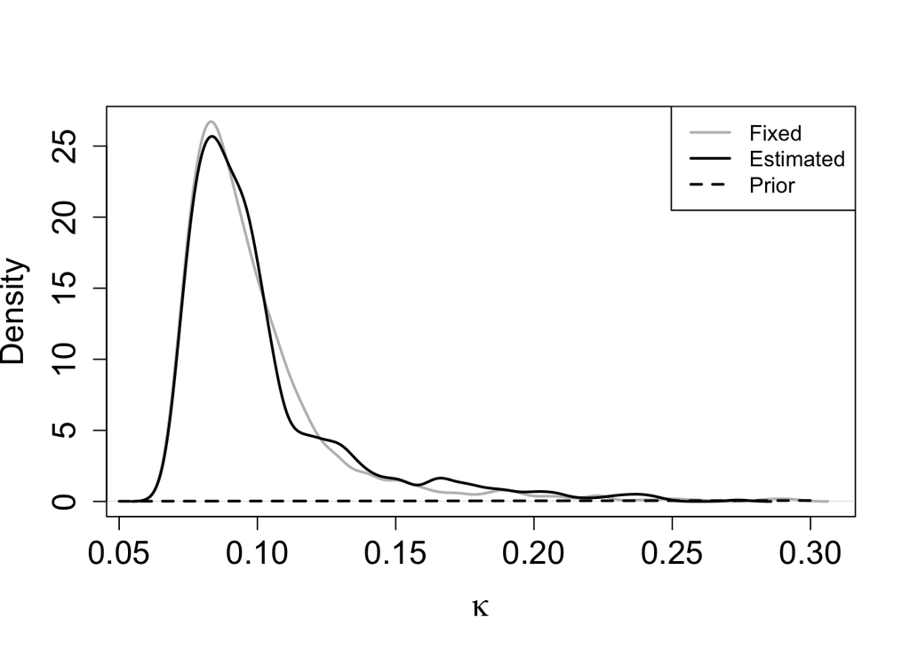

```r
plot(density(kappapHR), main = "", xlab = expression(kappa), ylab = "Density",
     cex.axis = 1.5, cex.lab = 1.5, lwd = 2, col = "gray")
points(density(kappapHRX), main = "", xlab = expression(kappa), ylab = "Density",
     cex.axis = 1.5, cex.lab = 1.5, lwd = 2, type = "l")
curve(p_kappaHR,0.05,0.3, n = 1000, xlab = ~kappa, ylab = "Prior Density",
      cex.axis = 1.5, cex.lab = 1.5, lwd = 2, lty = 2, add = TRUE)
legend("topright", legend = c("Fixed", "Estimated","Prior"), col = c("gray","black","black"),
       lty = c(1,1,2), lwd = c(2,2,2))
```

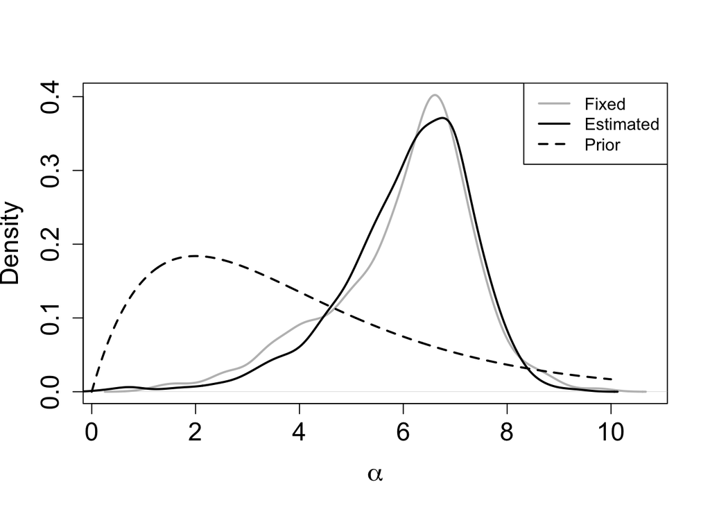

```r
plot(density(alphapHR), main = "", xlab = expression(alpha), ylab = "Density",
     cex.axis = 1.5, cex.lab = 1.5, lwd = 2, col = "gray")
points(density(alphapHRX), main = "", xlab = expression(alpha), ylab = "Density",
     cex.axis = 1.5, cex.lab = 1.5, lwd = 2, type = "l")
curve(p_alphaHR,0,10, n = 1000, xlab = ~alpha, ylab = "Prior Density",
      cex.axis = 1.5, cex.lab = 1.5, lwd = 2, lty = 2, add = TRUE)
legend("topright", legend = c("Fixed", "Estimated","Prior"), col = c("gray","black","black"),
       lty = c(1,1,2), lwd = c(2,2,2))
```

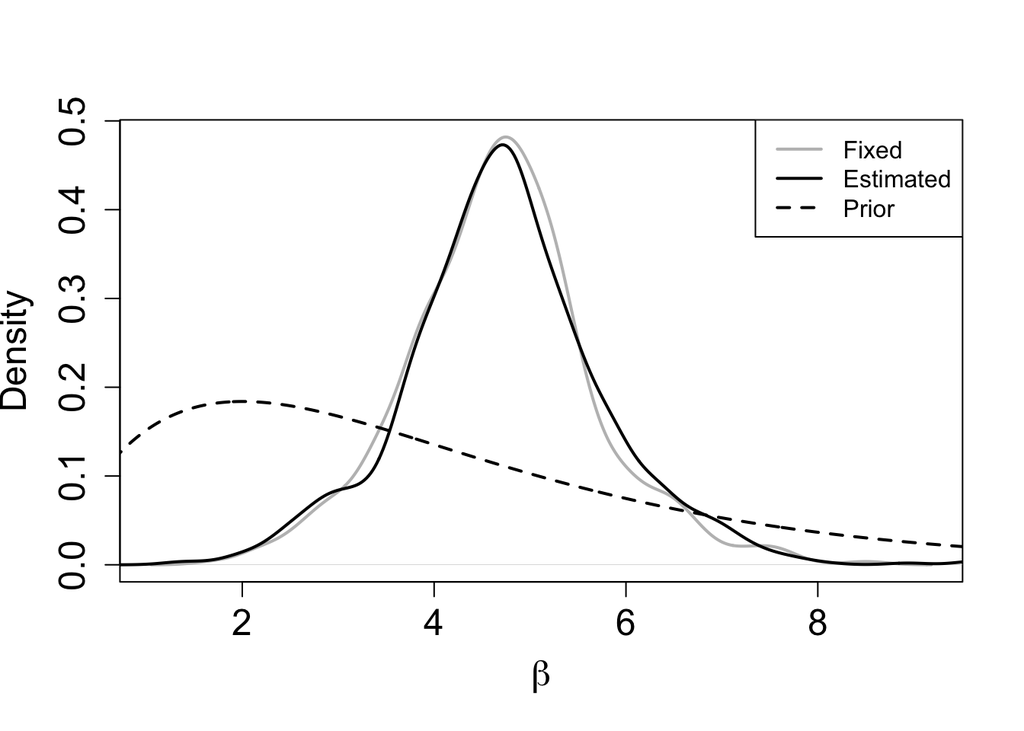

```r
plot(density(betapHR), main = "", xlab = expression(beta), ylab = "Density",
     cex.axis = 1.5, cex.lab = 1.5, lwd = 2, col = "gray")
points(density(betapHRX), main = "", xlab = expression(beta), ylab = "Density",
     cex.axis = 1.5, cex.lab = 1.5, lwd = 2, type = "l")
curve(p_betaHR,0,15, n = 1000, xlab = ~beta, ylab = "Prior Density",
      cex.axis = 1.5, cex.lab = 1.5, lwd = 2, lty = 2, add = TRUE)
legend("topright", legend = c("Fixed", "Estimated","Prior"), col = c("gray","black","black"),
       lty = c(1,1,2), lwd = c(2,2,2))
```

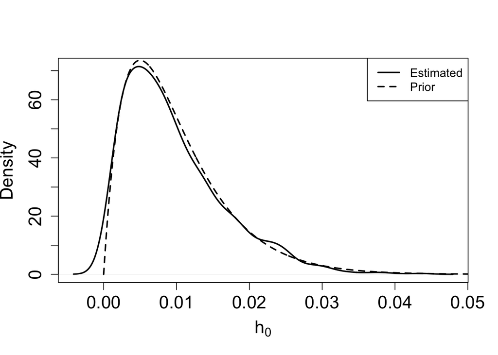

```r
p_h0HR <- Vectorize(function(t) dgamma(t, shape = 2, scale = 5e-3))
plot(density(h0pHRX), main = "", xlab = expression(h[0]), ylab = "Density",
     cex.axis = 1.5, cex.lab = 1.5, lwd = 2)
curve(p_h0HR,0,0.05, n = 1000, xlab = ~beta, ylab = "Prior Density",
      cex.axis = 1.5, cex.lab = 1.5, lwd = 2, lty = 2, add = TRUE)
legend("topright", legend = c("Estimated", "Prior"), col = c("black","black"),
       lty = c(1,2), lwd = c(2,2))
```

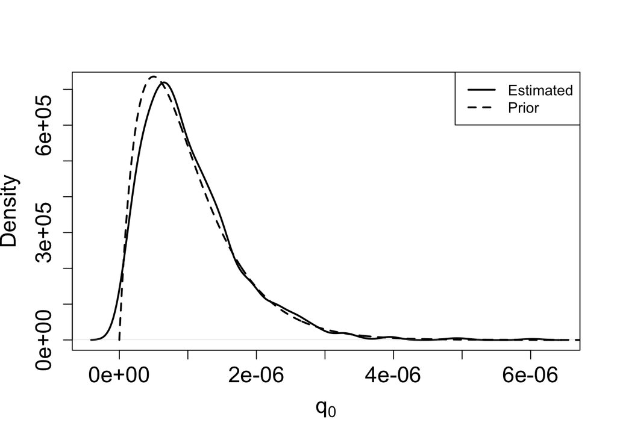

```r
p_q0HR <- Vectorize(function(t) dgamma(t, shape = 2, scale = 5e-7))
plot(density(q0pHRX), main = "", xlab = expression(q[0]), ylab = "Density",
     cex.axis = 1.5, cex.lab = 1.5, lwd = 2)
curve(p_q0HR,0,7e-6, n = 1000, xlab = ~beta, ylab = "Prior Density",
      cex.axis = 1.5, cex.lab = 1.5, lwd = 2, lty = 2, add = TRUE)
legend("topright", legend = c("Estimated", "Prior"), col = c("black","black"),
       lty = c(1,2), lwd = c(2,2))
```

```r
######################################################################################################
# Kernel density estimator (PDF)
######################################################################################################
# x:    vector of quantiles
# h:    smoothing parameter (bandwidth)
# data: data set

# Function
kde.dnorm <- function(x,h,data) mean( dnorm( x-data, 0, h ) )


##############################################################################
# h0 distance
##############################################################################

hh0 <- bw.nrd0(log(h0pHRX))
# Transformed KDE
kde.dh0 <- Vectorize(function(x) kde.dnorm(log(x),hh0,log(h0pHRX))/x)

diffh0 <- Vectorize(function(t) abs(kde.dh0(t) - p_h0HR(t)))

integrate(diffh0,0,0.1)
```

```
## 0.08189424 with absolute error < 0.00012
```

```r
##############################################################################
# q0 distance
##############################################################################

hq0 <- bw.nrd0(log(q0pHRX))
# Transformed KDE
kde.dq0 <- Vectorize(function(x) kde.dnorm(log(x),hq0,log(q0pHRX))/x)

diffq0 <- Vectorize(function(t) abs(kde.dq0(t) - p_q0HR(t)))

integrate(diffq0,0,1e-5)
```

```
## 0.06235697 with absolute error < 5e-05
```

Christen, J. A., and F. J. Rubio. 2024. “Dynamic Survival Analysis: Modelling the Hazard Function via Ordinary Differential Equations.” *Statistical Methods in Medical Research*.